# A6-International Flights to Brazil Analysis

### ANALISE DOS VOOS INTERNACIONAIS PARA O BRASIL

Há muito tempo sem brincar com os dados, então resolvi pesquisar e coletar na Internet alguns dados abertos para preencher o meu tempo e a minha cabeça. Encontrei disponível no Portal da ANAC estes dados de 2015, sobre a aviação comercial no Brasil. E rapidamente algumas perguntas/curiosidades vieram em minha mente:

1. *Qual é o comportamento dos voos internacionais no Brasil no período de 1 ano?*
2. *Quais são os Aeroportos (Top10) com um grande volume de voos para o Brasil?*
3. *Quais são os Aeroportos (Botton10) com um pequeno volume de voos para o Brasil?*
4. *Quais são os Aeroportos brasileiros (Top10) com grande chegada de voos internacionais?*
5. *Quais são as CIAs AEREA que mais fazem voo para o Brasil?*
6. *Durante os meses de maior tráfego quem são os Países com grande volume de voos para o Brasil?*
7. *Durante os meses de maior tráfego quais são os aeroportos brasileiros com grande chegada de voos internacionais?*
8. *Durante os meses de maior tráfego quais são as CIAs que mais fazem voo para o Brasil?*
9. *Durante os meses de maior tráfego este volume de voos internacionais para o Brasil é representado por pessoas vindo conhecer o País ou brasileiros saindo para o exterior?*
10. *Qual é comportamento dos voos que chegam ou saem do Brasil, estão lotados ou vazios?*

Bem, estas são algumas das perguntas/curiosidades que eu gostaria de obter respostas. Então, vamos ao desafio de buscar respostas para estes questionamentos e alguns outros insights.

*Iniciamos este notebook, importando as bibliotecas que iremos usar. Neste notebook estou usando o Python3 e as seguintes bibliotecas: pandas e matplotlib.*

```python
import pandas as pd
import matplotlib
import matplotlib.pyplot as plt
import numpy as np

%matplotlib inline
matplotlib.style.use('ggplot')
```

*Definição das variáveis de localização do arquivo (caminho) e nome-do-arquivo (CSV) que contem os dados que iremos estudar e analisar.*

```python
path = '/home/lserra/Temp/'
filename = 'anac2015.csv'
```

*Usamos a biblioteca Pandas para ler o arquivo CSV e carregar os dados para dentro de um DataFrame.*

```python
flights = pd.read_csv(path + filename, sep=';', encoding='latin1', header=0, parse_dates=[[u'MES',u'ANO']])
```

*Depois dos dados serem carregados para dentro de um DataFrame, executamos este comando abaixo que nos lista a estrutura dos dados e os tipos de dados que foram identificados automaticamente. Isto é muito importante para que possamos ter a certeza de que os cálculos entre as colunas irão funcionar e não teremos nenhum erro de tipo de dado inválido ou incompátivel.*

```python
flights.dtypes
```

```
MES_ANO                                               datetime64[ns]
EMPRESA (SIGLA)                                               object
EMPRESA (NOME)                                                object
EMPRESA (NACIONALIDADE)                                       object
AEROPORTO DE ORIGEM (SIGLA)                                   object
AEROPORTO DE ORIGEM (NOME)                                    object
AEROPORTO DE ORIGEM (UF)                                      object
AEROPORTO DE ORIGEM (REGIAO)                                  object
AEROPORTO DE ORIGEM (PAIS)                                    object
AEROPORTO DE ORIGEM (CONTINENTE)                              object
AEROPORTO DE DESTINO (SIGLA)                                  object
AEROPORTO DE DESTINO (NOME)                                   object
AEROPORTO DE DESTINO (UF)                                     object
AEROPORTO DE DESTINO (REGIAO)                                 object
AEROPORTO DE DESTINO (PAIS)                                   object
AEROPORTO DE DESTINO (CONTINENTE)                             object
NATUREZA                                                      object
GRUPO DE VOO                                                  object
PASSAGEIROS PAGOS                                            float64
PASSAGEIROS GRATIS                                           float64
CARGA PAGA (KG)                                              float64
CARGA GRATIS (KG)                                            float64
CORREIO (KG)                                                 float64
ASK                                                          float64
RPK                                                          float64
ATK                                                          float64
RTK                                                          float64
COMBUSTIVEL (LITROS) - APENAS EMPRESAS BRASILEIRAS           float64
DISTANCIA VOADA (KM)                                         float64
DECOLAGENS                                                   float64
CARGA PAGA KM                                                float64
CARGA GRATIS KM                                              float64
CORREIO KM                                                   float64
ASSENTOS                                                     float64
PAYLOAD                                                      float64
HORAS VOADAS                                                 float64
dtype: object
```

*Com este outro comando abaixo podemos ter uma dimensão dos dados que estamos estudando/analisando. Neste caso, temos 44.195 linhas distribuídas em 36 colunas.*

```python
flights.shape
```

```
(44195, 36)
```

*Em seguida, vamos listar as cinco primeiras linhas do DataFrame. Desta forma, podemos ter uma ideia preliminar de como são e estão os dados.*

```python
flights.head()
```

|  | MES_ANO | EMPRESA (SIGLA) | EMPRESA (NOME) | EMPRESA (NACIONALIDADE) | AEROPORTO DE ORIGEM (SIGLA) | AEROPORTO DE ORIGEM (NOME) | AEROPORTO DE ORIGEM (UF) | AEROPORTO DE ORIGEM (REGIAO) | AEROPORTO DE ORIGEM (PAIS) | AEROPORTO DE ORIGEM (CONTINENTE) | ... | RTK | COMBUSTIVEL (LITROS) - APENAS EMPRESAS BRASILEIRAS | DISTANCIA VOADA (KM) | DECOLAGENS | CARGA PAGA KM | CARGA GRATIS KM | CORREIO KM | ASSENTOS | PAYLOAD | HORAS VOADAS |
| --- | --- | --- | --- | --- | --- | --- | --- | --- | --- | --- | --- | --- | --- | --- | --- | --- | --- | --- | --- | --- | --- |
| 0 | 2015-01-01 | AAL | AMERICAN AIRLINES | ESTRANGEIRA | KDFW | DALLAS/FORT WORTH | NaN | NaN | ESTADOS UNIDOS | AMÉRICA DO NORTE | ... | 1629190.446 | NaN | 109239.0 | 13.0 | 1.741354e+08 | 0.0 | 34527927.0 | 2756.0 | 455000.0 | NaN |
| 1 | 2015-01-01 | AAL | AMERICAN AIRLINES | ESTRANGEIRA | KDFW | DALLAS/FORT WORTH | NaN | NaN | ESTADOS UNIDOS | AMÉRICA DO NORTE | ... | 7150724.525 | NaN | 254975.0 | 31.0 | 1.596851e+09 | 0.0 | 654652425.0 | 9610.0 | 1705000.0 | NaN |
| 2 | 2015-01-01 | AAL | AMERICAN AIRLINES | ESTRANGEIRA | KJFK | NEW YORK | NaN | NaN | ESTADOS UNIDOS | AMÉRICA DO NORTE | ... | 3205164.379 | NaN | 215684.0 | 28.0 | 2.775160e+08 | 0.0 | 316331398.0 | 5927.0 | 980000.0 | NaN |
| 3 | 2015-01-01 | AAL | AMERICAN AIRLINES | ESTRANGEIRA | KJFK | NEW YORK | NaN | NaN | ESTADOS UNIDOS | AMÉRICA DO NORTE | ... | 5531617.668 | NaN | 221444.0 | 29.0 | 8.663729e+08 | 0.0 | 363122344.0 | 8990.0 | 1595000.0 | NaN |
| 4 | 2015-01-01 | AAL | AMERICAN AIRLINES | ESTRANGEIRA | KJFK | NEW YORK | NaN | NaN | ESTADOS UNIDOS | AMÉRICA DO NORTE | ... | 1257498.643 | NaN | 91653.0 | 12.0 | 2.669775e+08 | 0.0 | 0.0 | 2621.0 | 420000.0 | NaN |

5 rows × 36 columns

*Como podemos observar no resultado da célula anterior, existem colunas que deveriam ter dados mas possuem valores 'nulos' e que são representados por 'NaN'. Poderíamos tratar estes dados de alguma forma, mas acho que estas colunas não afetarão o nosso trabalho. Então, podemos prosseguir: precisamos verificar qual o período de dados existente neste conjunto de dados. Para isso, identificamos qual é a menor e a maior data e depois calculamos a diferença entre as datas.*

```python
flights[u'MES_ANO'].min()
```

```
Timestamp('2015-01-01 00:00:00')
```

```python
flights[u'MES_ANO'].max()
```

```
Timestamp('2015-12-01 00:00:00')
```

```python
tempo = flights[u'MES_ANO'].max() - flights[u'MES_ANO'].min()
tempo
```

```
Timedelta('334 days 00:00:00')
```

*Eu percebi que não existem duas informações que podem ser muito importantes em nossas análises. São elas: 'qtde. de passageiros total' e 'qtde. de assentos vagos'. Mas, estas informações podem ser produzidas a partir das informações já existentes. Vamos chamar estas novas colunas de 'passageiros total' e 'assentos vagos'.*

```python
flights['PASSAGEIROS TOTAL'] = flights[u'PASSAGEIROS PAGOS'] + flights[u'PASSAGEIROS GRATIS']
flights['ASSENTOS VAGOS'] = flights[u'ASSENTOS'] - flights[u'PASSAGEIROS TOTAL']
```

##### Como podemos descrever o nosso conjunto de dados?

*Antes de mergulhar nos dados em busca das respostas para estas questões, vamos analisar algumas métricas estatísticas que poderão nos ajudar a entender como os nossos dados estão distribuídos. E desta forma podemos dizer se este conjunto de dados é: muito variável, volátil, disperso, menos consistente ou prevesível. Para isso, criamos um novo DataFrame chamado 'flights_hist', somente com as colunas: decolagens, passageiros total e assentos vagos. São todas colunas numéricas do tipo 'float'. Em seguida, aplicamos a função 'describe()' que gera várias métricas estatísticas. Esta função não leva em consideração os valores NaN. E para aumentar a compreensão destas várias métricas, também vamos gerar para cada coluna do DataFrame, um gráfico de histograma.*

```python
flights_hist = flights[['DECOLAGENS', 'PASSAGEIROS TOTAL', 'ASSENTOS VAGOS']]
```

```python
print(flights_hist.describe())
```

```
         DECOLAGENS  PASSAGEIROS TOTAL  ASSENTOS VAGOS
count  37349.000000       42658.000000    35812.000000
mean      29.161343        2806.374631     1161.009634
std       50.599681        5588.025467     2618.363953
min        0.000000           0.000000    -5843.000000
25%        1.000000           0.000000        0.000000
50%       11.000000         426.000000      294.000000
75%       31.000000        3366.750000     1427.000000
max      845.000000       87388.000000    78586.000000
```

```
Valor médio: 29.161343007844923
Valor mediano: 11.0
```

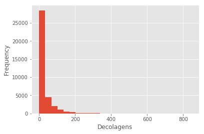

```python
print('Valor médio: ' + str(flights_hist['DECOLAGENS'].mean()))
print('Valor mediano: ' + str(flights_hist['DECOLAGENS'].median()))
flights_hist['DECOLAGENS'].plot.hist(bins=25)
plt.xlabel('Decolagens')
```

```
Valor médio: 2806.374630784378
Valor mediano: 426.0
```

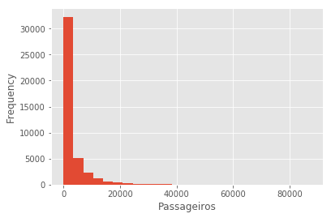

```python
print('Valor médio: ' + str(flights_hist['PASSAGEIROS TOTAL'].mean()))
print('Valor mediano: ' + str(flights_hist['PASSAGEIROS TOTAL'].median()))
flights_hist['PASSAGEIROS TOTAL'].plot.hist(bins=25)
plt.xlabel('Passageiros')
```

```
Valor médio: 1161.0096336423546
Valor mediano: 294.0
```

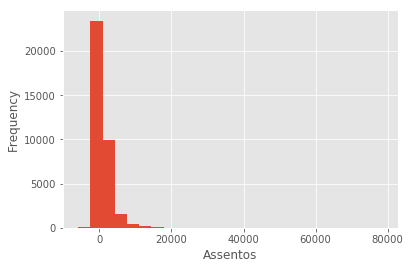

```python
print('Valor médio: ' + str(flights_hist['ASSENTOS VAGOS'].mean()))
print('Valor mediano: ' + str(flights_hist['ASSENTOS VAGOS'].median()))
flights_hist['ASSENTOS VAGOS'].plot.hist(bins=25)
plt.xlabel('Assentos')
```

*Farei algumas observações sobre este nosso conjunto de dados, mas não irei me aprofundar muito:*

*Já fizemos algumas inferências em nosso conjunto de dados, então agora, vamos buscar respostas para as questões descritas anteriormente:*

##### *Qual é o comportamento dos voos internacionais no Brasil no período de 1 ano?*

*Sabemos que neste nosso conjunto de dados possuímos quase 1 ano (334 dias), mas que será suficiente para responder esta questão*

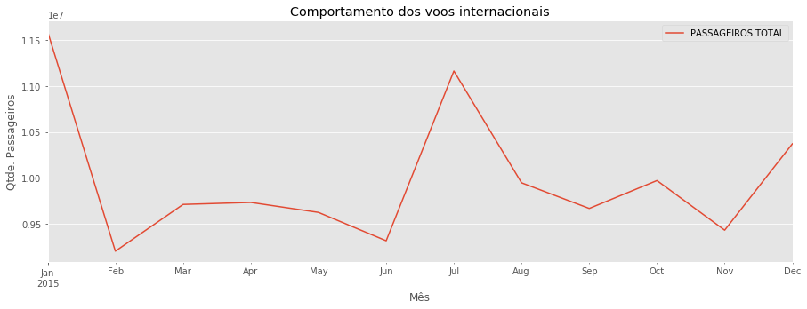

```python
flights.groupby(u'MES_ANO')[u'PASSAGEIROS TOTAL'].sum().plot(figsize=(15,5), label=u'PASSAGEIROS TOTAL')
plt.title(u'Comportamento dos voos internacionais')
plt.legend()
plt.xlabel(u'Mês')
plt.ylabel(u'Qtde. Passageiros')
plt.show()
```

*A partir deste momento criamos dois subconjuntos de dados. Isto se faz necessário para as próximas perguntas que vem a seguir.*

```python
inbound_flights = flights[ (flights[u'AEROPORTO DE DESTINO (PAIS)'] == 'BRASIL') &
                           (flights[u'PASSAGEIROS TOTAL'] > 0) &
                           (flights[u'AEROPORTO DE ORIGEM (PAIS)'] != 'BRASIL')
                             ]
```

```python
outbound_flights = flights[(flights[u'AEROPORTO DE DESTINO (PAIS)'] != 'BRASIL') &
                           (flights[u'PASSAGEIROS TOTAL'] > 0) &
                           (flights[u'AEROPORTO DE ORIGEM (PAIS)'] == 'BRASIL')
                              ]
```

*O subconjunto de dados chamado de 'inboud_flights', trata dos voos/passageiros que estão entrando no Brasil. E o subconjunto de dados chamado de 'outbound_flights', trata dos voos/passageiros que estão saindo do Brasil. Agora vamos colocar estes dados em um gráfico para uma maior compreensão do comportamento dos passageiros que entram e saem do Brasil.*

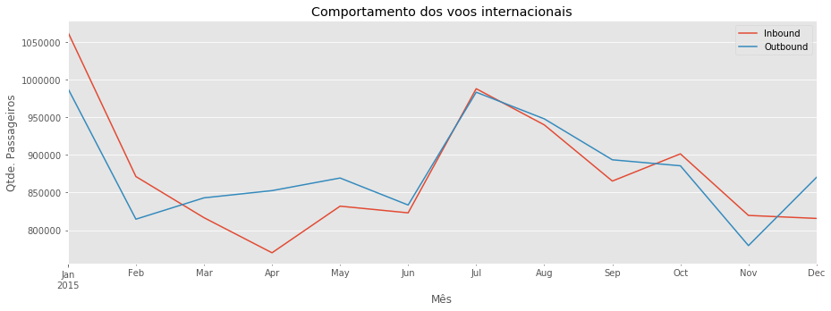

```python
inbound_flights.groupby(u'MES_ANO')['PASSAGEIROS TOTAL'].sum().plot(figsize=(15,5), label='Inbound')
outbound_flights.groupby(u'MES_ANO')['PASSAGEIROS TOTAL'].sum().plot(figsize=(15,5), label='Outbound')
plt.title(u'Comportamento dos voos internacionais')
plt.legend()
plt.xlabel(u'Mês')
plt.ylabel(u'Qtde. Passageiros')
plt.show()
```

*Este gráfico acima nos dá uma boa ideia de como é o fluxo (volume) de voos/passageiros nos aeroportos brasileiros durante o período de 1 ano. A linha vermelha representa, os passageiros que estão entrando no Brasil. A linha azul representa, os passageiros que estão saindo do Brasil. Podemos perceber que durante os meses entre junho a julho o fluxo de passageiros aumenta bastante e que a variação de pessoas que entram ou que saem do Brasil em algum momento tende a zero.*

##### *Quais são os Aeroportos (Top10) com um grande volume de voos para o Brasil?*

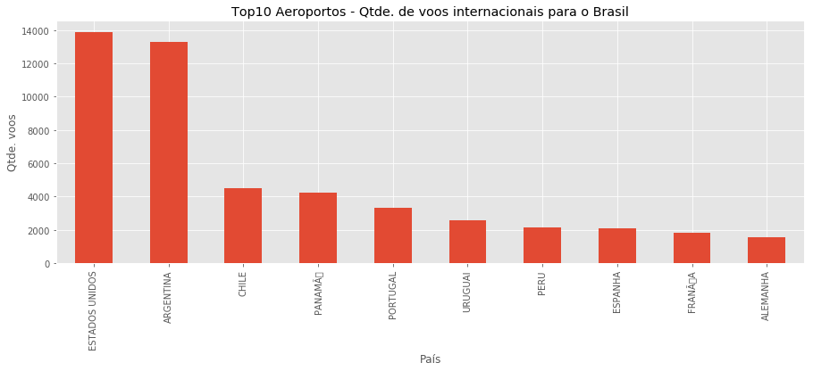

```python
inbound_flights_by_airport = inbound_flights.groupby([u'AEROPORTO DE ORIGEM (PAIS)'])
top10 = inbound_flights_by_airport[u'DECOLAGENS'].sum().sort_values(ascending=False)[:10]  # 10 primeiras linhas
top10.plot(kind='bar', figsize=(15,5))
plt.title(u'Top10 Aeroportos - Qtde. de voos internacionais para o Brasil')
plt.xlabel(u'País')
plt.ylabel(u'Qtde. voos')
plt.show()
```

##### *Quais são os Aeroportos (Botton10) com um pequeno volume de voos para o Brasil?*

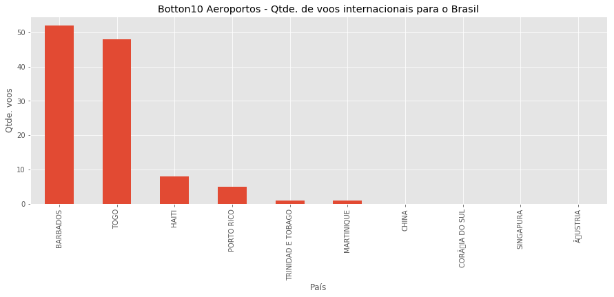

```python
inbound_flights_by_airport = inbound_flights.groupby([u'AEROPORTO DE ORIGEM (PAIS)'])
botton10 = inbound_flights_by_airport[u'DECOLAGENS'].sum().sort_values(ascending=False)[-10:]  # 10 últimas linhas
botton10.plot(kind='bar', figsize=(15,5))
plt.title(u'Botton10 Aeroportos - Qtde. de voos internacionais para o Brasil')
plt.xlabel(u'País')
plt.ylabel(u'Qtde. voos')
plt.show()
```

##### *Quais são os Aeroportos brasileiros (Top10) com grande chegada de voos internacionais?*

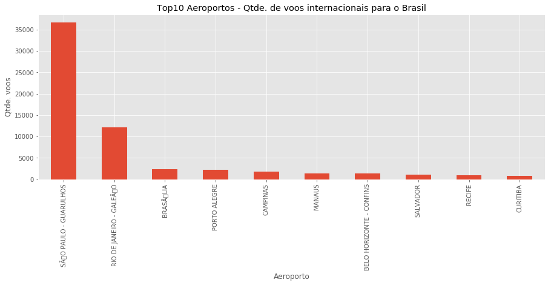

```python
inbound_flights_by_airport = inbound_flights.groupby([u'AEROPORTO DE DESTINO (NOME)'])
top10 = inbound_flights_by_airport[u'DECOLAGENS'].sum().sort_values(ascending=False)[:10]
top10.plot(kind='bar', figsize=(15,5))
plt.title(u'Top10 Aeroportos - Qtde. de voos internacionais para o Brasil')
plt.xlabel(u'Aeroporto')
plt.ylabel(u'Qtde. voos')
plt.show()
```

##### *Quais são as CIAs que mais fazem voo para o Brasil?*

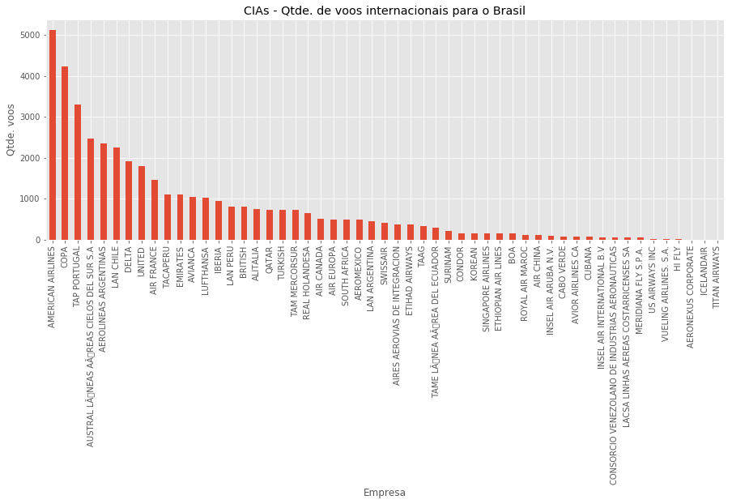

```python
inbound_flights_by_cia = inbound_flights[ (inbound_flights[u'EMPRESA (NACIONALIDADE)'] == 'ESTRANGEIRA')]
cias = inbound_flights_by_cia.groupby(u'EMPRESA (NOME)')[u'DECOLAGENS'].sum().sort_values(ascending=False)
cias.plot(kind='bar', figsize=(15,5))
plt.title(u'CIAs - Qtde. de voos internacionais para o Brasil')
plt.xlabel(u'Empresa')
plt.ylabel(u'Qtde. voos')
plt.show()
```

*Na primeira parte da nossa análise ao carregar os dados para o DataFrame ('flights'), criamos uma coluna chamada 'MES_ANO' para facilitar a nossa análise de série temporal. Mas, a partir deste momento precisamos mudar a forma como iremos analisar os dados. E esta coluna 'MES_ANO' não será mais útil. Poderíamos criar outras duas colunas: 'MES' e 'ANO' derivada a partir desta coluna já existente. Mas, sinceramente é mais fácil carregar novamente os dados para este DataFrame. Pois estas informações já existem em nosso conjunto de dados.*

```python
flights = pd.read_csv(path + filename, sep=';', encoding='latin1', header=0)
```

```python
flights.columns
```

```
Index(['EMPRESA (SIGLA)', 'EMPRESA (NOME)', 'EMPRESA (NACIONALIDADE)', 'ANO',
       'MES', 'AEROPORTO DE ORIGEM (SIGLA)', 'AEROPORTO DE ORIGEM (NOME)',
       'AEROPORTO DE ORIGEM (UF)', 'AEROPORTO DE ORIGEM (REGIAO)',
       'AEROPORTO DE ORIGEM (PAIS)', 'AEROPORTO DE ORIGEM (CONTINENTE)',
       'AEROPORTO DE DESTINO (SIGLA)', 'AEROPORTO DE DESTINO (NOME)',
       'AEROPORTO DE DESTINO (UF)', 'AEROPORTO DE DESTINO (REGIAO)',
       'AEROPORTO DE DESTINO (PAIS)', 'AEROPORTO DE DESTINO (CONTINENTE)',
       'NATUREZA', 'GRUPO DE VOO', 'PASSAGEIROS PAGOS', 'PASSAGEIROS GRATIS',
       'CARGA PAGA (KG)', 'CARGA GRATIS (KG)', 'CORREIO (KG)', 'ASK', 'RPK',
       'ATK', 'RTK', 'COMBUSTIVEL (LITROS) - APENAS EMPRESAS BRASILEIRAS',
       'DISTANCIA VOADA (KM)', 'DECOLAGENS', 'CARGA PAGA KM',
       'CARGA GRATIS KM', 'CORREIO KM', 'ASSENTOS', 'PAYLOAD', 'HORAS VOADAS'],
      dtype='object')
```

*Precisamos recriar as colunas: 'PASSAGEIROS TOTAL' e 'ASSENTOS VAGOS'*

```python
flights['PASSAGEIROS TOTAL'] = flights[u'PASSAGEIROS PAGOS'] + flights[u'PASSAGEIROS GRATIS']
flights['ASSENTOS VAGOS'] = flights[u'ASSENTOS'] - flights[u'PASSAGEIROS TOTAL']
```

*Precisamos criar um novo subconjunto de dados. Desta vez, baseado nos meses de maior tráfego e somente nos voos/passageiros que estão entrando no Brasil. Se voltarmos para a questão 1, iremos perceber que os meses de maior tráfego de voos/passageiros, são: janeiro (1), julho (7), outubro (10) e dezembro (12).*

```python
inbound_flights = flights[ (flights[u'AEROPORTO DE DESTINO (PAIS)'] == 'BRASIL') &
                           (flights[u'PASSAGEIROS TOTAL'] > 0) &
                           (flights[u'AEROPORTO DE ORIGEM (PAIS)'] != 'BRASIL') &
                           (flights[u'EMPRESA (NACIONALIDADE)'] == 'ESTRANGEIRA') &
                           (flights[u'MES'].isin([1,7,10,12]))  # meses de pico
                             ]
outbound_flights = flights[ (flights[u'AEROPORTO DE DESTINO (PAIS)'] != 'BRASIL') &
                            (flights[u'PASSAGEIROS TOTAL'] > 0) &
                            (flights[u'AEROPORTO DE ORIGEM (PAIS)'] == 'BRASIL') &
                            (flights[u'EMPRESA (NACIONALIDADE)'] != 'ESTRANGEIRA') &
                            (flights[u'MES'].isin([1,7,10,12]))  # meses de pico
                             ]
```

##### *Durante os meses de maior tráfego quais são os Países com grande volume de voos para o Brasil?*

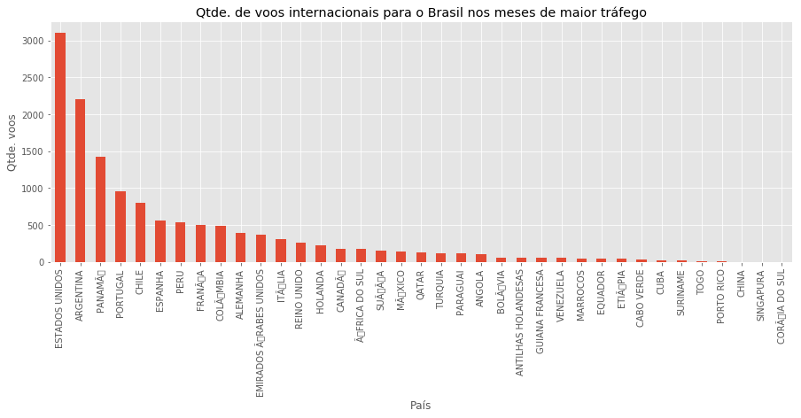

```python
inbound_flights_by_month = inbound_flights.groupby(u'AEROPORTO DE ORIGEM (PAIS)')[u'DECOLAGENS'].sum().sort_values(ascending=False)
inbound_flights_by_month.plot(kind='bar', figsize=(15,5))
plt.title(u'Qtde. de voos internacionais para o Brasil nos meses de maior tráfego')
plt.xlabel(u'País')
plt.ylabel(u'Qtde. voos')
plt.show()
```

##### *Durante os meses de maior tráfego quais são os aeroportos brasileiros com grande chegada de voos internacionais?*

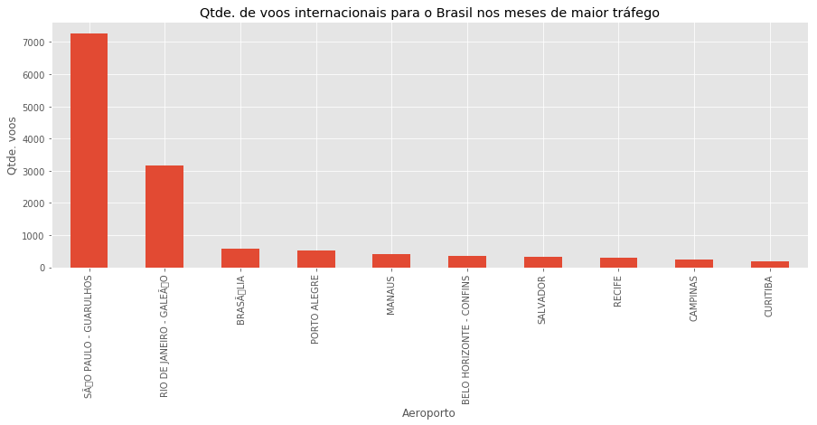

```python
inbound_flights_by_month = inbound_flights.groupby([u'AEROPORTO DE DESTINO (NOME)'])[u'DECOLAGENS'].sum().sort_values(ascending=False)[:10]
inbound_flights_by_month.plot(kind='bar', figsize=(15,5))
plt.title(u'Qtde. de voos internacionais para o Brasil nos meses de maior tráfego')
plt.xlabel(u'Aeroporto')
plt.ylabel(u'Qtde. voos')
plt.show()
```

##### *Durante os meses de maior tráfego quais são as CIAs que mais fazem voo para o Brasil?*

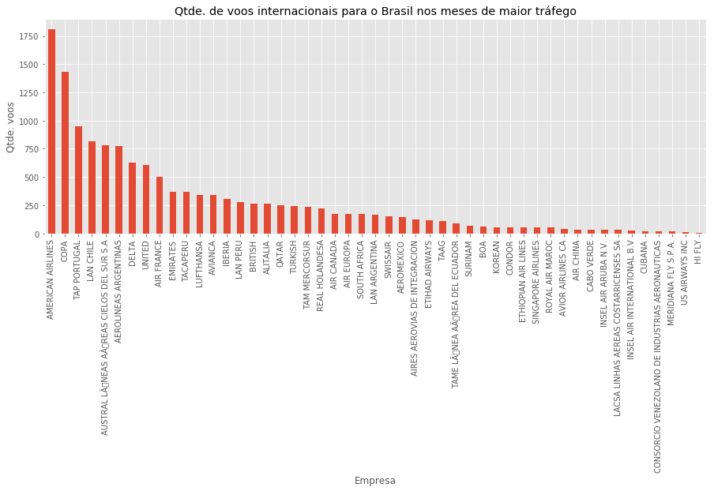

```python
inbound_flights_by_month = inbound_flights.groupby([u'EMPRESA (NOME)'])[u'DECOLAGENS'].sum().sort_values(ascending=False)
inbound_flights_by_month.plot(kind='bar', figsize=(15,5))
plt.title(u'Qtde. de voos internacionais para o Brasil nos meses de maior tráfego')
plt.xlabel(u'Empresa')
plt.ylabel(u'Qtde. voos')
plt.show()
```

##### *Durante os meses de maior tráfego este volume de voos internacionais para o Brasil é representado por pessoas vindo conhecer o País ou brasileiros saindo para o exterior?*

*Esta questão requer o alinhamento de algumas premissas. Em nosso conjunto de dados não há a identificaçao dos passageiros que estão nos voos que chegam/saem ao Brasil. Desta forma, fica difícil responder com assertividade. Mas, vamos partir do princípio de que todos os voos que estão chegando estão trazendo passageiros de outras nacionalidades e que os voos que estão saindo estão levando passageiros brasileiros.*

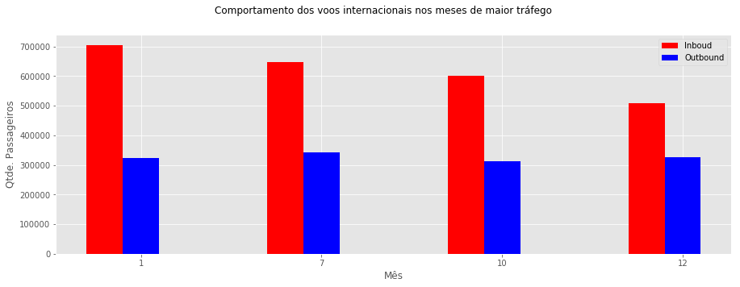

```python
# --- Side by side bar chart
# --- get the data
inbound = np.array(inbound_flights.groupby(u'MES')['PASSAGEIROS TOTAL'].sum())
outbound = np.array(outbound_flights.groupby(u'MES')['PASSAGEIROS TOTAL'].sum())
labels=['1', '7', '10', '12']
# --- the plot – inbound then outbound
fig, ax = plt.subplots(figsize=(15, 5))
width = 0.2 # bar width
xlocs = np.arange(len(inbound))
ax.bar(xlocs-width, inbound, width, color='red', label='Inboud')
ax.bar(xlocs, outbound, width, color='blue', label='Outbound')
# --- labels, grids, title, etc
ax.set_xticks(ticks=range(len(inbound)))
ax.set_xticklabels(labels)
ax.yaxis.grid(True)
ax.legend(loc='best')
ax.set_xlabel(u'Mês')
ax.set_ylabel(u'Qtde. Passageiros')
fig.suptitle(u'Comportamento dos voos internacionais nos meses de maior tráfego')
```

##### *Qual é comportamento dos voos que chegam ou saem do Brasil, estão lotados ou vazios?*

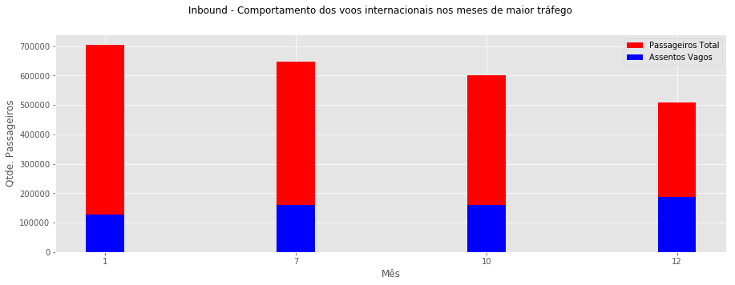

```python
# --- Side by side bar chart: Inbounds
# --- get the data
inbound_a = np.array(inbound_flights.groupby(u'MES')['PASSAGEIROS TOTAL'].sum())
inbound_v = np.array(inbound_flights.groupby(u'MES')['ASSENTOS VAGOS'].sum())
labels=['1', '7', '10', '12']
# --- the plot – inbound_a then inbound_v
fig, ax = plt.subplots(figsize=(15, 5))
width = 0.2 # bar width
xlocs = np.arange(len(inbound_a))
ax.bar(xlocs, inbound_a, width, color='red', label='Passageiros Total')
ax.bar(xlocs, inbound_v, width, color='blue', label='Assentos Vagos')
# --- labels, grids, title, etc
ax.set_xticks(ticks=range(len(inbound_a)))
ax.set_xticklabels(labels)
ax.yaxis.grid(True)
ax.legend(loc='best')
ax.set_xlabel(u'Mês')
ax.set_ylabel(u'Qtde. Passageiros')
fig.suptitle(u'Inbound - Comportamento dos voos internacionais nos meses de maior tráfego')
```

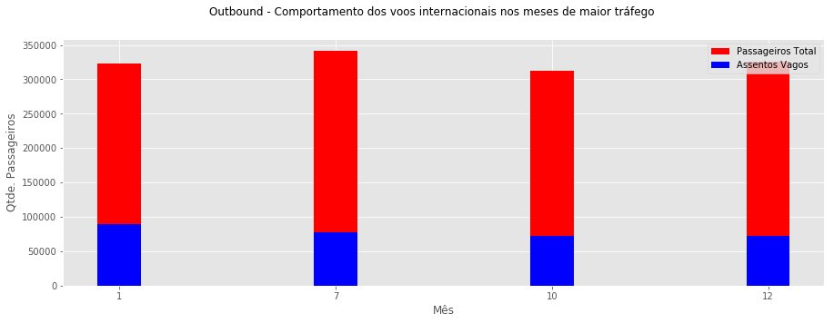

```python
# --- Side by side bar chart: Outbounds
# --- get the data
outbound_a = np.array(outbound_flights.groupby(u'MES')['PASSAGEIROS TOTAL'].sum())
outbound_v = np.array(outbound_flights.groupby(u'MES')['ASSENTOS VAGOS'].sum())
labels=['1', '7', '10', '12']
# --- the plot – inbound_a then inbound_v
fig, ax = plt.subplots(figsize=(15, 5))
width = 0.2 # bar width
xlocs = np.arange(len(outbound_a))
ax.bar(xlocs, outbound_a, width, color='red', label='Passageiros Total')
ax.bar(xlocs, outbound_v, width, color='blue', label='Assentos Vagos')
# --- labels, grids, title, etc
ax.set_xticks(ticks=range(len(outbound_a)))
ax.set_xticklabels(labels)
ax.yaxis.grid(True)
ax.legend(loc='upper right')
ax.set_xlabel(u'Mês')
ax.set_ylabel(u'Qtde. Passageiros')
fig.suptitle(u'Outbound - Comportamento dos voos internacionais nos meses de maior tráfego')
```

##### *CONCLUSAO:*

*Estas foram as minhas observações que podem ser expandidas e contribuídas por quem possuir interesse. Querendo me contatar para esclarecer dúvidas, fazer sugestões ou críticas...ou mesmo contratar os meus serviços - basta enviar um e-mail para: laercio.serra@gmail.com, ou saiba mais em: http://lserra.datafresh.com.br*